# Sommaire

# CHI2 méthode 1 et 2 pour verifier

```python
# Table de contingence pour Chi²:
# chi2 table de contingence
X = "sex"    # qualitative
Y = "categ" # qualitative

cont = achats[[X,Y]].pivot_table(index=X,columns=Y,aggfunc=len,margins=True,margins_name="Total")
cont
```

| categ sex | 0.0 | 1.0 | 2.0 | Total |
| --- | --- | --- | --- | --- |
| f | 206220 | 114899 | 17283 | 338402 |
| m | 209460 | 112270 | 19200 | 340930 |
| Total | 415680 | 227169 | 36483 | 679332 |

```python
# Chi²:
import scipy.stats as st
st_chi2, st_p, st_dof, st_exp = st.chi2_contingency(cont)

print("Les fréquences théoriques sont:\n", st_exp)
# degré de liberté ddl = nbligne-1 * nbColonne-1 ==> 4-1*3-1 = 3*2 = 6 = ddl = st_dof
print(f"Ce qui donne un X² de {st_chi2:.3f} à", st_dof, "ddl")
print(f"soit une p-value de", st_p)
```

```
Les fréquences théoriques sont:
 [[207066.56444861 113161.81769444  18173.61785695 338402.        ]
 [208613.43555139 114007.18230556  18309.38214305 340930.        ]
 [415680.         227169.          36483.         679332.        ]]
Ce qui donne un X² de 147.003 à 6 ddl
soit une p-value de 3.327978654785752e-29
```

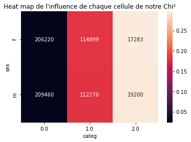

```python
tx = cont.loc[:,["Total"]]
ty = cont.loc[["Total"],:]
n = len(achats)
indep = tx.dot(ty) / n

c = cont.fillna(0) # On remplace les valeurs nulles par 0
measure = (c-indep)**2/indep
xi_n = measure.sum().sum()
table = measure/xi_n
sns.heatmap(table.iloc[:-1,:-1],annot=c.iloc[:-1,:-1],fmt='d')
plt.title("Heat map de l'influence de chaque cellule de notre Chi²")
plt.savefig("assets/graphiques/ 12 lien entre genre et catégorie de livre acheté")
plt.show()
```

```python
# khi2 entre sex et montant p4C5
X = "sex"
Y = "categ"
cont = achats[[X,Y]].pivot_table(index=X,columns=Y,aggfunc=len,margins=True,margins_name="Total")
```

[output not shown]

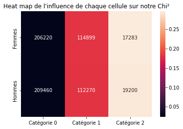

```python
# On crée categ_sex pour enlever les totaux et pouvoir fair un heatmap
categ_sex=achats[[X,Y]].pivot_table(index=X,columns=Y,aggfunc=len,margins=False)
# Heat map pour identifier les cellules les plus influantes sur le Chi²:
# Création et initialisation du tableau a 0
len_i = categ_sex.shape[0] # 2
len_j = categ_sex.shape[1] # 3
xij = np.zeros((len_i, len_j)) # initialisation à 0
#xij
# boucle
for i in range(len_i):
    for j in range(len_j):
        xij[i,j] = (categ_sex.values[i,j]-st_exp[i,j])**2 / st_exp[i,j]
#xij
# heatmap
sns.heatmap(xij/st_chi2,
            annot=categ_sex, # on ecrit dans les cases
            fmt='d', # on enlève l'écriture scientifique (format decimal)
            yticklabels=["Femmes","Hommes"],# label des x
            xticklabels=["Catégorie 0", "Catégorie 1", "Catégorie 2"]) # label des y
plt.title("Heat map de l'influence de chaque cellule sur notre Chi²") #titre
plt.plot()
```

- **L'hypothèse nulle : Il n'existe pas de lien entre les catégories achetées et le genre.**
  - Que l'on prenne un seuil à 5% (0,05) ou 1% (0,01), la p-value sera ici toujours très inférieure au seuil de significativité,
  - **l'hypothèse nulle est rejetée**,
- **L'hypothèse alternative HA est retenue les catégories des livres achetées dépendent du genre de l'acheteur.** Il y a bien une dépendance entre le genre et le sexe (cf catégorie 2)

[figure not shown]

## le lien entre l’âge des clients et le montant total des achats

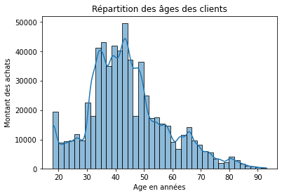

```python
sns.histplot(data=df["age"],
             bins=40,
             kde=True)
plt.title("Répartition des âges des clients")
plt.ylabel("Montant des achats")
plt.xlabel("Age en années")
plt.savefig("assets/graphiques/13.1 Lien entre l'age des clients et le montant des achats.png")
plt.show()
```

```python
# test de student
```

```python
from scipy.stats import ttest_ind
ttest_ind(achats['age'], achats['price'])
```

```
Ttest_indResult(statistic=966.2513360457239, pvalue=0.0)
```

```python
# Ajout des tranches d'ages au df achats:
achats["age_rank"] = pd.cut(x= achats["age"], bins=[17,37,57,77,100], include_lowest=False, ordered=True)
#achats.head()

# Repartition des montants des achats d'ages et montant:
repartition_achats_age_rank = achats.groupby(["age_rank"])["price"].sum()
print("montant total des achats par tranches d'age:\n", repartition_achats_age_rank)

# Nombre d'achats par tranches d'ages:
nbr_achats_age_rank = achats.groupby(["age_rank"])["price"].count()
print("nombre total d'achats par tranches d'age:\n",nbr_achats_age_rank)

# Montant moyen des achats par tranches d'ages:
moy_achats_age_rank = achats.groupby(["age_rank"])["price"].mean()
print("montant moyen des achats par tranches d'age:\n", moy_achats_age_rank)
```

```
montant total des achats par tranches d'age:
 age_rank
(17, 37]     5064750.89
(37, 57]     5031521.58
(57, 77]     1526947.87
(77, 100]     232716.13
Name: price, dtype: float64
nombre total d'achats par tranches d'age:
 age_rank
(17, 37]     213655
(37, 57]     360725
(57, 77]      91110
(77, 100]     13842
Name: price, dtype: int64
montant moyen des achats par tranches d'age:
 age_rank
(17, 37]     23.705277
(37, 57]     13.948358
(57, 77]     16.759388
(77, 100]    16.812320
Name: price, dtype: float64
```

- Les 17-37 ans ont les panier moyens les plus élevés (23.7)
- Les 37-57 ans ont les paniers moyens les moins élevés (13.9)
- Ces 2 tranches rapportent autant de CA l'une que l'autres (17, 37] Les 37-57 achète plus de produits que les 17-37

```
Corrélation de Spearman: SpearmanrResult(correlation=-0.8576076555023923, pvalue=4.57972879340901e-23)
Corrélation de Pearson :  (-0.7788615764587009, 1.198396010000492e-16)
```

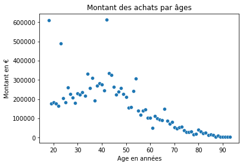

```python
# Lien entre l'age et le montant des achats:
age = achats.groupby(["age"])["client_id"].count()

# total des achats par age
tot_achats_age = achats.groupby(["age"])["price"].sum()

# Correlation entre l'age et le montant total des achats:
print("Corrélation de Spearman:", st.spearmanr(tot_achats_age.index, tot_achats_age.values))
print("Corrélation de Pearson : ",st.pearsonr(tot_achats_age.index,tot_achats_age.values))
# expliquer les corrélations
# Graphique:
sns.scatterplot(data= tot_achats_age)
plt.ylabel("Montant en €")
plt.xlabel("Age en années")
plt.title("Montant des achats par âges")
plt.savefig("assets/graphiques/13.2 Montants des achats par âges.png")
```

## la fréquence d’achat

- le lien entre l’âge des clients et la fréquence d’achat
- Distribution empirique de la variable
  - modalité | effectif | frequence
    - les modalités : client_id, years, month | frequence : nb sessionid nunique
      - modalité : client_id | moyenne de session par mois

```python
# Fréquence d'achat en moyenne par mois
tmp = achats.groupby(["client_id","years","month"])["session_id"].nunique()
frequence_mensuelle= tmp.groupby("client_id").mean().reset_index()
print(tmp)
print(frequence_mensuelle)
# En moyenne le client c_1 fait 1.9 achat par mois
```

```
client_id  years  month
c_1        2021   6        1
                  7        4
                  8        1
                  9        2
                  10       1
                          ..
c_999      2022   10       1
                  11       2
                  12       1
           2023   1        4
                  2        1
Name: session_id, Length: 137134, dtype: int64
     client_id  session_id
0          c_1    1.941176
1         c_10    2.125000
2        c_100    1.000000
3       c_1000    4.227273
4       c_1001    2.350000
...        ...         ...
8595     c_995    1.125000
8596     c_996    3.434783
8597     c_997    1.263158
8598     c_998    1.642857
8599     c_999    2.210526

[8600 rows x 2 columns]
```

```python
# ajouter les ages au df : jointure outer avec customer
frequence_mensuelle = pd.merge(frequence_mensuelle,customers, on="client_id", how="outer")
frequence_mensuelle.head()
# on a un df client|moyenne fréquence achat| sex| naissance|age
```

|  | client_id | session_id | sex | birth | age |
| --- | --- | --- | --- | --- | --- |
| 0 | c_1 | 1.941176 | m | 1955 | 67 |
| 1 | c_10 | 2.125000 | m | 1956 | 66 |
| 2 | c_100 | 1.000000 | m | 1992 | 30 |
| 3 | c_1000 | 4.227273 | f | 1966 | 56 |
| 4 | c_1001 | 2.350000 | m | 1982 | 40 |

```python
frequence_mensuelle.isna().mean()*100
```

```
client_id     0.000000
session_id    0.243591
sex           0.000000
birth         0.000000
age           0.000000
dtype: float64
```

```python
# suppression des na
frequence_mensuelle = frequence_mensuelle.dropna() # ceux qui n'ont rien acheté
frequence_mensuelle.isna().mean()*100
```

```
client_id     0.0
session_id    0.0
sex           0.0
birth         0.0
age           0.0
dtype: float64
```

```python
# Lien entre l'age et la fréquence achat mensuelle
frequence_age = frequence_mensuelle.groupby(['age'])['session_id'].sum()
print(round(frequence_age,2))
```

```
age
18    629.96
19    204.12
20    202.09
21    181.12
22    192.34
       ...
89     14.95
90     11.42
91      6.61
92      8.07
93      6.51
Name: session_id, Length: 76, dtype: float64
```

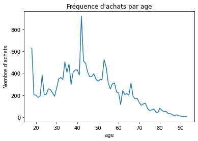

```python
frequence_age.plot()
plt.title("Fréquence d'achats par age")
plt.ylabel("Nombre d'achats")
plt.savefig("assets/graphiques/13.4 fequence_age.png")
```

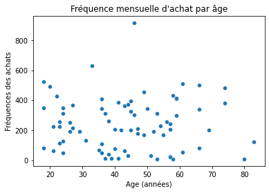

```python
# Graphique
sns.scatterplot(x=frequence_mensuelle["age"], y=frequence_age)
plt.ylabel("Fréquences des achats")
plt.xlabel("Age (années)")
plt.title("Fréquence mensuelle d'achat par âge")
plt.savefig("assets/graphiques/13.3 Fréquences mensuelles achats par ages.png")
```

Coefficient de corrélation calculé sur les numéros d’ordre des valeurs des deux variables ordinales.

Le coefficient de corrélation sur les rangs (Rho de Spearman) s’interprète de la même manière qu’un coefficient de corrélation de Pearson : une valeur positive (maximum = +1) indique une variation simultanée dans le même sens, une valeur négative (minimum = -1) une variation simultanée en sens inverse.

La différence entre les deux coefficients repose sur la nature des valeurs numériques. Le coefficient de Pearson est calculé à partir des données brutes des variables numériques. Le Rho de Spearman est calculé sur les rangs d’échelles ordinales.

```python
# Correlation entre l'age et le montant total des achats
# Test d'association entre deux variables quantitatives
print("Corrélation de Spearman:", st.spearmanr(frequence_mensuelle["age"], frequence_mensuelle["session_id"]))
# La correlation n'est pas monotone elle n'est ni proche de 1 ni de -1 mais proche de 0
```

```
Corrélation de Spearman: SpearmanrResult(correlation=0.20589327229102006, pvalue=5.572887167216921e-83)
```